# Income and Relation to Social Categories

## Salary and Gender

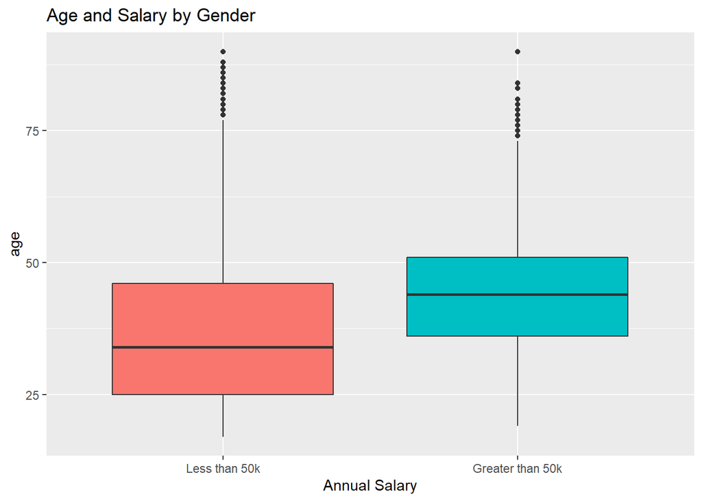

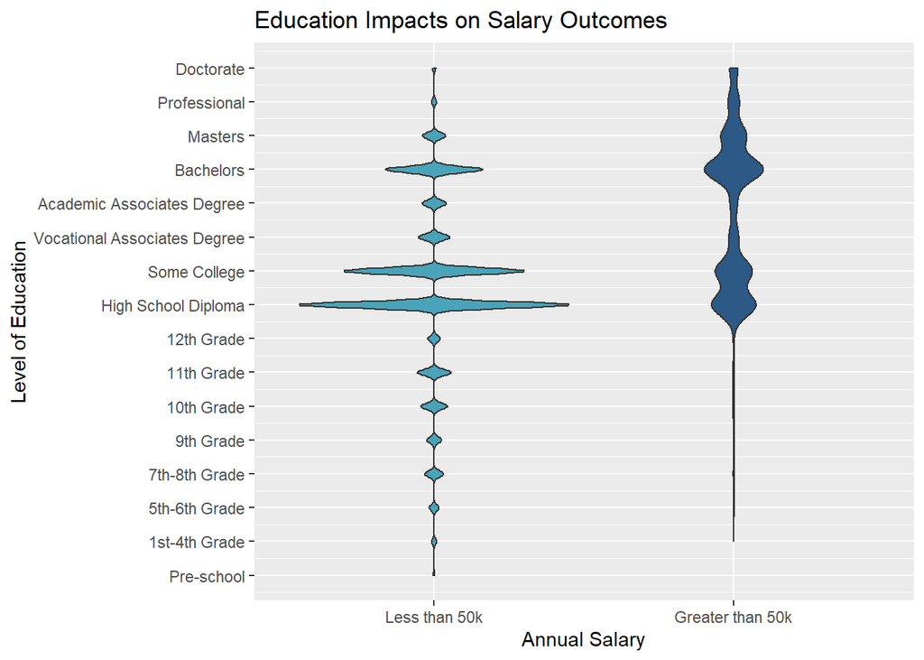

This plot offers helpful insights into the return on investment of post-secondary education and the impact of education on future outcomes. American post-secondary education is increasingly a luxury. While education and salary outcomes are often correlated, a college degree is not essential for success. Individuals considering a post-secondary degree should make informed decisions about their future. This visualization highlights the correlation between salary and education level, but also clarifies the limits of this correlation.